# Homework 6

# Preliminaries

- This file should be in `STAT240/homework/hw06` on your local computer.

# Problem 1

For each of the following descriptions, say whether the random variable is reasonably approximated by a binomial random variable or not, and explain your answer. If the variable is binomial, identify $n$ the number of trials and $p$ the probability of success. If it is not binomial, identify which of the “BINS” assumptions is violated.

1. A fair die is rolled until a 1 appears, and $X$ denotes the number of rolls.

Not binomial, since there is not a fixed number of trials.

2. Twenty of the different Badger basketball players each attempt 1 free throw and $X$ is the total number of successful attempts.

Not binomial, since the probability of success isn’t the same between players.

3. A die is rolled 50 times. Let $X$ be the face that lands up most often.

Not binomial, since the outcome is not a number of pre-defined successes.

4. In a bag of 10 batteries, I know 2 are old. Let $X$ be the number of old batteries I choose when taking a sample of 4 to put into my calculator.

Not binomial. A large sample size (4) relative to population size (10) means sampling without replacement will affect the additional draws, so the trials are not independent.

5. It is reported that 20% of Madison homeowners have installed a home security system. Let $X$ be the number of homes without home security systems installed in a random sample of 100 houses in the Madison city limits.

Binomial! 100 fixed trials, S = no home security installed, $p = 0.80$, $1-p = 0.20$, n = 100. The number of homes is so large, we can assume independence between homes in a random sample of just 100.

# Problem 2

1. Create a data frame with the following columns. Each row corresponds to a single $\text{Binom}(n, p)$ distribution. The first two columns are the parameters of the distribution.
- `n`, which is always equal to 100
- `p`, which ranges from 0 to 1 by 0.01 $(0, 0.01, 0.02, \ldots , 0.99, 1)$
- `mu`, the mean
- `sigma`, the standard deviation
- `q90`, the 0.9 quantile (or 90th percentile)

```r
binoms <-  tibble(
  n = 100,
  p = seq(0, 1, 0.01),
  mu = n*p,
  sigma = sqrt(n*p*(1-p)),
  q90 = qbinom(0.9, n, p))
```

2. Create line plots of the following:
- $\sigma$ versus $p$
- 90th percentile versus $p$

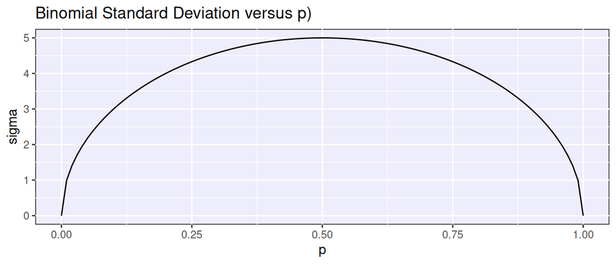

```r
ggplot(binoms, aes(x = p, y = sigma)) +
  geom_line() +
  xlab("p") +
  ylab("sigma") +
  ggtitle("Binomial Standard Deviation versus p)")
```

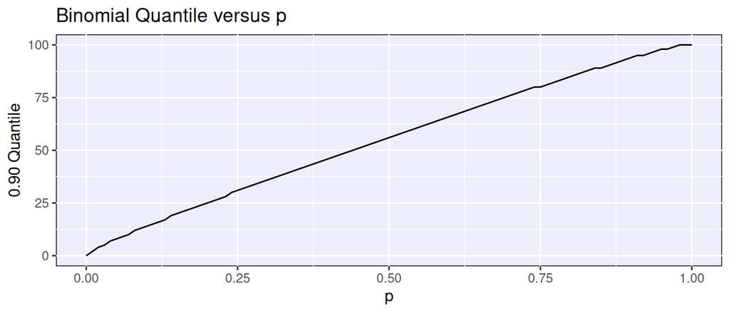

```r
ggplot(binoms, aes(x = p, y = q90)) +
  geom_line() +
  xlab("p") +
  ylab("0.90 Quantile") +
  ggtitle("Binomial Quantile versus p")
```

3. How does the standard deviation change with $p$?

The standard deviation is largest when $p = 0.5$. It gets smaller as $p$ gets closer to 0 and closer to 1.

4. Comment on the relationship between the 90th percentile and $p$.

As $p$ increases, the 90th percentile q90 does as well. However, this is a jagged and not smooth line, since the binomial is discrete, so there are “jumps” between different integers.

# Problem 3

The random variable $X$ has the $\text{Binom}(100, 0.2)$ distribution.

1. Find an integer $a$ so that $P(X \le a) \ge 0.5$. (There are many choices for $a$). Show the value of $P(X \le a)$ with `pbinom()`.

For $P(X \le a)$ to be at least 0.5, most of the probability of $X$ must be at or below $a$. One choice is $a = 30$, since $P(X \le 30) = 0.994$.

```r
pbinom(30, 100, 0.2)
```

```
## [1] 0.9939407
```

2. Find an integer $b$ so that $P(X \ge b) \ge 0.5$. (There are many choices for $b$). Show the value of $P(X \ge b)$ with `pbinom()`.

For $P(X \ge b)$ to be at least 0.5, most of the probability of $X$ must be at or above $b$. One choice is $b = 15$, since $P(X \ge 15) = 0.92$.

```r
1 - pbinom(14, 100, 0.2)
```

```
## [1] 0.9195563
```

3. Find an integer $c$ so that $P(X \le c) \ge 0.5$ *and* $P(X \ge c) \ge 0.5$. Show the values of $c$, $P(X \le c)$, and $P(X \ge c)$.

For $P(X \le c)$ and $P(X \ge c)$ to both be at least 0.5, $c$ must be a number close to the center of the probability. So, we’ll start by finding the 50th percentile of $X$ with `qbinom()`.

```r
qbinom(0.5, 100, 0.2)
```

```
## [1] 20
```

So $P(X \le 20)$ is at least 0.5. Using `pbinom()`, we can verify that $P(X \le 20)$ and $P(X \ge 20)$ are both more than 0.5.

```r
# P(X <= 20)
pbinom(20, 100, 0.2)
```

```
## [1] 0.5594616
```

```r
# P(X >= 20)
1 - pbinom(19, 100, 0.2)
```

```
## [1] 0.5398386
```

# Problem 4

A student decided to guess randomly on their True/False quiz. The number of questions they answer correctly is $\text{Binom}(10, 0.5)$. Write code with `dbinom`, `pbinom`, or `qbinom` to calculate each value or probability.

- “I know I must have gotten at least one question right!”

```r
# Probability of at least one correct answer
1 - dbinom(0, 10, 0.5)
```

```
## [1] 0.9990234
```

```r
# or
pbinom(0, 10, 0.5, lower.tail = F)
```

```
## [1] 0.9990234
```

- “I probably got 3 - 5 of the questions right.”

```r
# Probability of 3 - 5 (inclusive) correct answers
pbinom(5, 10, 0.5) - pbinom(2, 10, 0.5)
```

```
## [1] 0.5683594
```

- “I feel lucky. The answers I picked are better than 90% of my other attempts!”

```r
# 90th percentile
qbinom(0.9, 10, 0.5)
```

```
## [1] 7
```

Explain why the 90th percentile is not 9.

The percentile is calculated based on the probabilities of the different values in the population, not the 90th percentile of the values themselves. We can see that 7 is the smallest value of x such that $P(X \le x)$ is at least 0.9.

```r
pbinom(7, 10, 0.5)
```

```
## [1] 0.9453125
```

```r
pbinom(6, 10, 0.5)
```

```
## [1] 0.828125
```

# Problem 5

Match the four binomial distributions given below to the appropriate graph in `p5_choices.png`. Briefly justify your choices.

- Binom(12, 0.5)

Graph C. It must be one of the top 3 graphs, since the upper 3 have values from 0 to 12. For the probability to be 0.5, the graph of the distribution would have to be symmetric.

- Binom(12, 0.6)

Graph B. The probability is shifted slightly to the right of Graph C (e.g. 7 has more probability than 6) which reflects the fact that we have the same n but a larger p.

- Binom(10, 0.1)

Graph D. It must be one of the lower 3 graphs, since they have values from 0 to 10. Graph D has its probabilities very concentrated on the left side of the graph near 0 and 1.

- Binom(10, 0.3)

Graph E. The probability is shifted to the right compared to Graph D, but it is still primarily on the left side of the graph. It can’t be Graph F because F is perfectly symmetric.

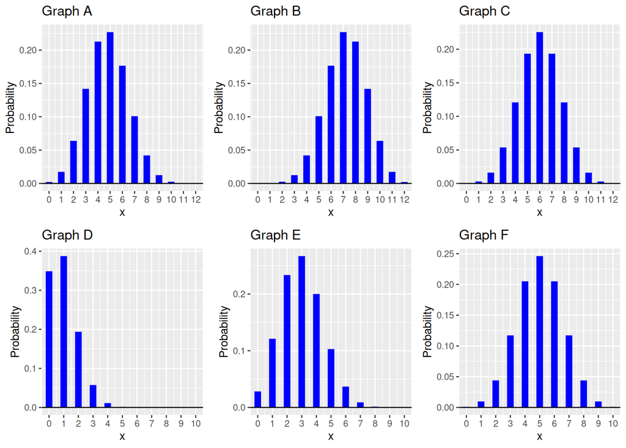

# Problem 6

1. Identify whether each of the statements below are *always true*, *sometimes true*, or *never true* for Binomial random variables. Briefly explain your answers. You can optionally use R to help make your argument.
- The distribution has no limits and covers the entire number line.

This is never true. A binomial random variable counts the number of successes in a fixed number of trials, so it has a limit in either direction. The minimum is 0 and the maximum is the number of trials $n$.

- The 50th percentile is less than the 60th percentile.

This is sometimes true. Because of how discrete percentiles are calculated, the 50th and 60th percentiles can be the same if there are very few possible values.

```r
# 50th and 60th percentiles are different in this case
qbinom(c(0.5, 0.6), size = 50, prob = 0.4)
```

```
## [1] 20 21
```

```r
# 50th and 60th percentiles are the same in this case
qbinom(c(0.5, 0.6), size = 3, prob = 0.6)
```

```
## [1] 2 2
```

- If $\mu$ is the mean of the distribution, then the probability distribution graphically reaches its maximum at $\mu$.

This is sometimes true, in the case of a symmetric binomial random variable with an odd number of possible values. But this is false for binomials with $p \neq 0.5$ or binomials where $\mu$ is not a possible value.

- If $\mu$ is the mean of the distribution, then the probability of getting exactly $\mu$ on a random draw is non-zero.

This is sometimes true, depending on whether $\mu$ is a possible value or not. For some binomial variables, $\mu$ is a decimal, which is impossible to observe.

```r
# 4 is the mean of Binom(16, 0.25)
dbinom(4, 16, 0.25)
```

```
## [1] 0.2251991
```

```r
# 2.4 is the mean of Binom(6, 0.4)
dbinom(2.4, 6, 0.4)
```

```
## [1] 0
```

2. Repeat part (a), but assess the truth of each statement for Normal random variables.
- The distribution has no limits and covers the entire number line.

This is always true. The tails stretch all the way to negative and positive infinity, although they get very very close to 0 outside of the bell-curve shape.

- The 50th percentile is less than the 60th percentile.

This is always true, since Normal RVs are continuous. The 50th and 60th percentiles make a “slice” of 10% of the area under the curve, so they must be different numbers.

```r
# 50th and 60th percentile of a standard normal
qnorm(c(0.5, 0.6))
```

```
## [1] 0.0000000 0.2533471
```

- If $\mu$ is the mean of the distribution, then the probability distribution graphically reaches its maximum at $\mu$.

This is always true for Normal RVs, since each one is a perfectly symmetric bell curve with its peak at $\mu$.

- If $\mu$ is the mean of the distribution, then the probability of getting exactly $\mu$ on a random draw is non-zero.

This is never true, since Normal RVs are continuous, and the probability of any individual point, $\mu$ or otherwise, is 0.

# Problem 7

Use `pnorm` to find the following probabilities on X ~ N(0, 1).

1. $P(X < -1)$

To find the area below a value, use pnorm’s default functionality.

```r
pnorm(-1)
```

```
## [1] 0.1586553
```

2. $P(X > 1)$

To find an area above, use subtraction or set `lower.tail = F`. This is also the same as the probability in (a).

```r
1 - pnorm(1)
```

```
## [1] 0.1586553
```

```r
# or
pnorm(1, lower.tail = F)
```

```
## [1] 0.1586553
```

3. $P(0.5 < X < 2)$

To find an area between two points, subtract two calls to pnorm.

```r
pnorm(2) - pnorm(0.5)
```

```
## [1] 0.2857874
```

4. $P(|X| > 0.75)$

We can add two calls to pnorm or take advantage of the fact that the curve is symmetric around 0.

```r
pnorm(-0.75) + pnorm(0.75, lower.tail = F)
```

```
## [1] 0.4532547
```

```r
# or
2 * pnorm(-0.75)
```

```
## [1] 0.4532547
```

# Problem 8

Let $X_1$ and $X_2$ be two draws from $X ~ N(10, 4)$. Order the five events below based on which events are least to most likely to occur.

- Event A: $X_1 > 15$
- Event B: $X_1 = 15$
- Event C: $X_1 < 15$
- Event D: $X_1 > 15$ AND $X_2 > 15$
- Event E: $X_1 > X_2$

Since $X$ is continuous, event B is impossible, since we can’t define probabilities at a specific point. We can find the probabilities of events A and C using pnorm.

```r
# Event A
pnorm(15, 10, 4, lower.tail = F)
```

```
## [1] 0.1056498
```

```r
# Event C
pnorm(15, 10, 4)
```

```
## [1] 0.8943502
```

$P(A) = 0.106$ and $P(C) = 0.894$. If event D happens, then that means we draw a value above 15 two times in a row, so $P(D) = 0.106 \cdot 0.106 = 0.011$. Finally, $P(E)$ is 0.5 by symmetry. We have B < D < A < E < C.